# HW7 Multiple Regression Yuefei Chen

Yuefei Chen

2024-04-12

## The first part: Rent house Data

### Model development

Running the following code, we build a multiple regression model based on rent house data. Its independent variables “area”, “rooms”, “bathroom”, “parking spaces”, “hoa”, “property tax”, “fire insurance”. The dependent variable is “rent amount”.

```r
library(readr)
house_data <- read_csv("Dataset/Rent_House_random_200_multi_regression.csv")
house_data <- house_data[, c(1:4, 6:11)]
str(house_data)
```

```
## tibble [200 × 10] (S3: tbl_df/tbl/data.frame)
##  $ area          : num [1:200] 120 45 50 35 204 177 15 70 180 180 ...
##  $ rooms         : num [1:200] 3 1 2 1 4 3 1 2 3 4 ...
##  $ bathroom      : num [1:200] 4 1 1 1 4 3 1 2 3 4 ...
##  $ parking_spaces: num [1:200] 3 1 1 0 2 4 0 1 2 2 ...
##  $ animal        : chr [1:200] "acept" "not acept" "acept" "acept" ...
##  $ furniture     : chr [1:200] "not furnished" "furnished" "not furnished" "not furnished" ...
##  $ hoa           : num [1:200] 1350 3000 226 260 0 2700 0 1800 700 2600 ...
##  $ rent_amount   : num [1:200] 5600 5520 750 1400 3440 6900 1200 4200 2700 2000 ...
##  $ property_tax  : num [1:200] 560 0 0 0 100 509 0 250 175 584 ...
##  $ fire_insurance: num [1:200] 71 70 10 18 62 89 16 55 40 26 ...
```

```r
reg_data <- house_data[,-c(5,6)]
fit <- lm(rent_amount~area+rooms+bathroom+parking_spaces+hoa+property_tax+fire_insurance, data=reg_data)
fit
```

```
##
## Call:
## lm(formula = rent_amount ~ area + rooms + bathroom + parking_spaces +
##     hoa + property_tax + fire_insurance, data = reg_data)
##
## Coefficients:
##    (Intercept)            area           rooms        bathroom  parking_spaces
##       54.01250        -2.49739       -67.89201        66.10065        33.40648
##            hoa    property_tax  fire_insurance
##        0.32035        -0.03111        73.32810
```

### Model Acceptance

In the summary of the model, we focus on R squared value, coefficients, and P-value of each coefficient. The R-squared value is 0.9835 and Adjust R-squared value is 0.9829. It shows there is a high proportion of variance in the dependent variable can be explained by the independent variables. The result of coefficient is shown in the following table. P-value result shows that the “area”, “hoa”, and “fire insurance” are variables which have a significant relationship with the “rent amount” variable. In addition, we use anova to compare full model and reduced model. The result shows that only keeping “area”, “hoa”, and “fire insurance” does not improve the model performance. Therefore, we use stepAIC to find an optimal model. It contains “area”, “rooms”, “bathroom”, “hoa”, “fire insurance”.

```r
summary(fit)
```

```
##
## Call:
## lm(formula = rent_amount ~ area + rooms + bathroom + parking_spaces +
##     hoa + property_tax + fire_insurance, data = reg_data)
##
## Residuals:
##     Min      1Q  Median      3Q     Max
## -2170.3  -126.8    -9.6   109.1  4011.7
##
## Coefficients:
##                 Estimate Std. Error t value Pr(>|t|)
## (Intercept)     54.01250   76.47149   0.706  0.48085
## area            -2.49739    0.63604  -3.926  0.00012 ***
## rooms          -67.89201   41.35463  -1.642  0.10229
## bathroom        66.10065   45.03771   1.468  0.14383
## parking_spaces  33.40648   35.91696   0.930  0.35349
## hoa              0.32035    0.03715   8.623 2.42e-15 ***
## property_tax    -0.03111    0.04246  -0.733  0.46466
## fire_insurance  73.32810    1.23463  59.393  < 2e-16 ***
## ---
## Signif. codes:  0 '***' 0.001 '**' 0.01 '*' 0.05 '.' 0.1 ' ' 1
##
## Residual standard error: 453.1 on 192 degrees of freedom
## Multiple R-squared:  0.9835, Adjusted R-squared:  0.9829
## F-statistic:  1634 on 7 and 192 DF,  p-value: < 2.2e-16
```

```r
coefficients(fit)
```

```
##    (Intercept)           area          rooms       bathroom parking_spaces
##     54.0124954     -2.4973875    -67.8920130     66.1006537     33.4064754
##            hoa   property_tax fire_insurance
##      0.3203464     -0.0311120     73.3281041
```

```r
library(MASS)
fit1 <- fit
fit2 <- lm(rent_amount ~ area + hoa + fire_insurance, data = reg_data)
# compare models
anova(fit1, fit2)
```

```
## Analysis of Variance Table
##
## Model 1: rent_amount ~ area + rooms + bathroom + parking_spaces + hoa +
##     property_tax + fire_insurance
## Model 2: rent_amount ~ area + hoa + fire_insurance
##   Res.Df      RSS Df Sum of Sq      F Pr(>F)
## 1    192 39425392
## 2    196 40564017 -4  -1138625 1.3863 0.2402
```

```r
step <- stepAIC(fit, direction="both")
```

```
## Start:  AIC=2454.32
## rent_amount ~ area + rooms + bathroom + parking_spaces + hoa +
##     property_tax + fire_insurance
##
##                  Df Sum of Sq       RSS    AIC
## - property_tax    1    110224  39535616 2452.9
## - parking_spaces  1    177638  39603031 2453.2
## <none>                         39425392 2454.3
## - bathroom        1    442317  39867709 2454.6
## - rooms           1    553432  39978824 2455.1
## - area            1   3165776  42591168 2467.8
## - hoa             1  15268698  54694090 2517.8
## - fire_insurance  1 724340651 763766043 3045.1
##
## Step:  AIC=2452.88
## rent_amount ~ area + rooms + bathroom + parking_spaces + hoa +
##     fire_insurance
##
##                  Df Sum of Sq       RSS    AIC
## - parking_spaces  1    145498  39681115 2451.6
## <none>                         39535616 2452.9
## - bathroom        1    432197  39967813 2453.1
## - rooms           1    508595  40044211 2453.4
## + property_tax    1    110224  39425392 2454.3
## - area            1   3974795  43510411 2470.0
## - hoa             1  16784818  56320434 2521.7
## - fire_insurance  1 787848804 827384420 3059.1
##
## Step:  AIC=2451.61
## rent_amount ~ area + rooms + bathroom + hoa + fire_insurance
##
##                  Df Sum of Sq       RSS    AIC
## <none>                         39681115 2451.6
## - rooms           1    524159  40205274 2452.2
## + parking_spaces  1    145498  39535616 2452.9
## - bathroom        1    657291  40338406 2452.9
## + property_tax    1     78084  39603031 2453.2
## - area            1   3903457  43584571 2468.4
## - hoa             1  17055295  56736410 2521.1
## - fire_insurance  1 788294198 827975313 3057.2
```

```r
fit3 <- lm(rent_amount ~ area + rooms + bathroom + hoa + fire_insurance, data = reg_data)
```

### Residual Analysis

```r
confint(fit3,level=0.95)
```

```
##                       2.5 %      97.5 %
## (Intercept)     -95.5543465 203.9133827
## area             -3.6077450  -1.3634035
## rooms          -146.6132114  15.2417940
## bathroom         -7.6949583 161.2625040
## hoa               0.2443655   0.3790055
## fire_insurance   71.2507593  75.9265335
```

```r
fitted(fit3)
```

[output not shown]

```r
residuals(fit3)
```

[output not shown]

[output cut: 13 more lines]

[output not shown]

```r
library(car)
```

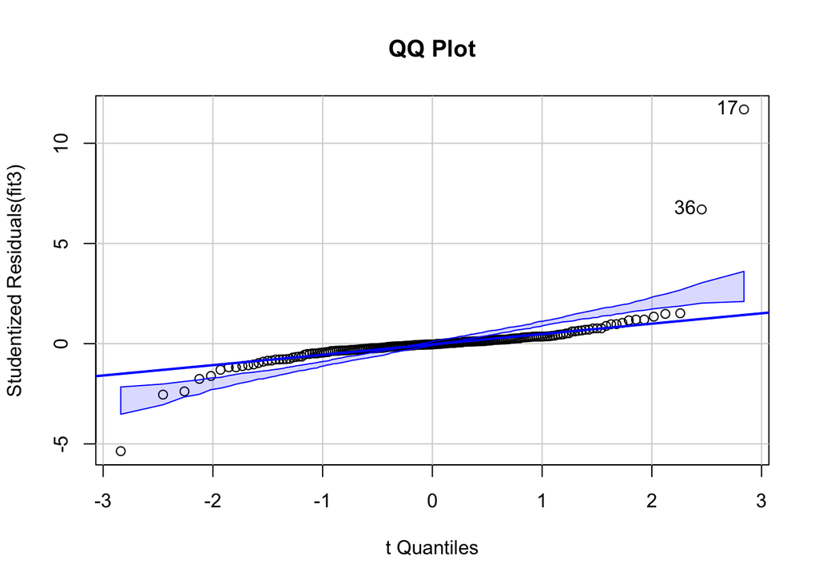

```
## [1] 17 36
```

```r
qqPlot(fit3, main="QQ Plot")
```

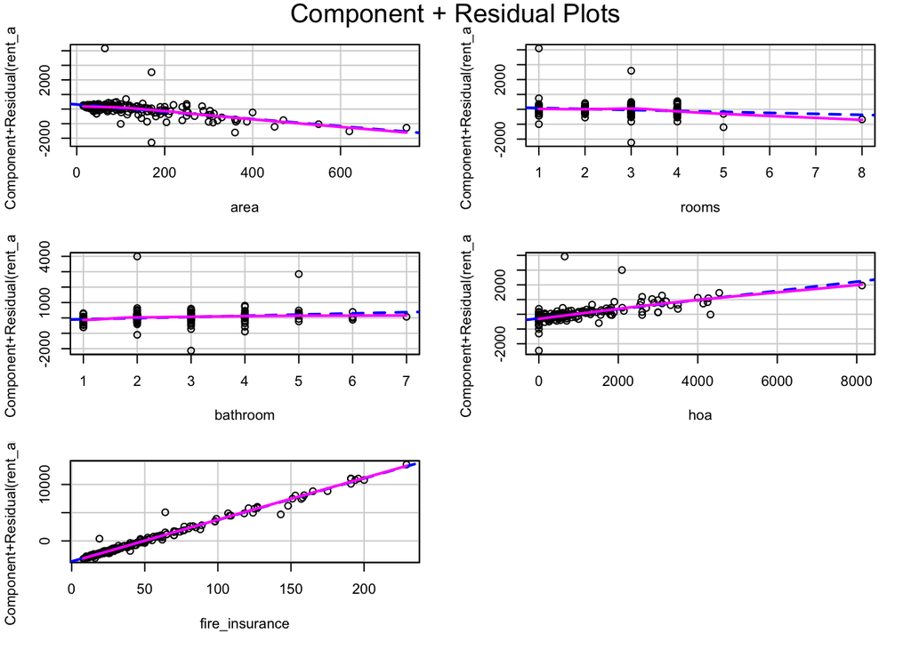

```r
crPlots(fit3)
```

```r
predict.lm(fit3, data.frame(area = 120, rooms = 3, bathroom = 2, hoa = 0, fire_insurance = 50))
```

```
##        1
## 3391.853
```

### Model Accuracy

The accuracy is based on summary of the model and we also calculate the MSE and RMSE for the model. The R-squared value is 0.9834, and the Adjusted R-squared value is 0.983. The MSE is 198405.6 and RMSE is 445.4274.

```r
summary(fit3)
```

```
##
## Call:
## lm(formula = rent_amount ~ area + rooms + bathroom + hoa + fire_insurance,
##     data = reg_data)
##
## Residuals:
##     Min      1Q  Median      3Q     Max
## -2188.1  -129.5   -17.7    94.1  4004.7
##
## Coefficients:
##                 Estimate Std. Error t value Pr(>|t|)
## (Intercept)     54.17952   75.91965   0.714   0.4763
## area            -2.48557    0.56897  -4.369 2.04e-05 ***
## rooms          -65.68571   41.03272  -1.601   0.1110
## bathroom        76.78377   42.83330   1.793   0.0746 .
## hoa              0.31169    0.03413   9.131  < 2e-16 ***
## fire_insurance  73.58865    1.18538  62.080  < 2e-16 ***
## ---
## Signif. codes:  0 '***' 0.001 '**' 0.01 '*' 0.05 '.' 0.1 ' ' 1
##
## Residual standard error: 452.3 on 194 degrees of freedom
## Multiple R-squared:  0.9834, Adjusted R-squared:  0.983
## F-statistic:  2296 on 5 and 194 DF,  p-value: < 2.2e-16
```

```r
predictions <- predict(fit3, reg_data)
mse <- mean((reg_data$rent_amount - predictions)^2)
rmse <- sqrt(mse)
cat("MSE: ", mse, "\n")
```

```
## MSE:  198405.6
```

```r
cat("RMSE: ", rmse, "\n")
```

```
## RMSE:  445.4274
```